# Project_Final_1

## PART 1 : Downloading the company basic info data

```python
%pip install wrds
```

Question(Q1 & Q2 ) 1 and 2 import libraries and verify your identity

```python
cd
```

```
C:\Users\DELL
```

```python
import datetime
print(datetime.datetime.now())
```

```
2024-11-23 20:04:17.320353
```

Q3 -> connect WRDS API

```python
#importing libraries
import pandas as pd
import wrds
```

```python
#connecting WRDS using your ID and password
conn=wrds.Connection()
```

```
WRDS recommends setting up a .pgpass file.
```

```
You can create this file yourself at any time with the create_pgpass_file() function.
Loading library list...
Done
```

Q4 -> download the company basic info data- columns including 'siccd', 'permno,' 'ticker','comnam', 'cusip', and 'namedt'

```python
#q4 solution
info_crsp=conn.get_table(library='crsp', table='stocknames', columns =['siccd', 'permno', 'ticker','comnam', 'cusip','namedt'])
```

Q5 -> change the format of 'namedt' to Panda’s date format

```python
#q5 solution
info_crsp['namedt']=pd.to_datetime(info_crsp['namedt'])
```

Q6-> check duplicates based on 'permno’ (i.e., count the total number of duplicates)

```python
#q6 solution
info_crsp.duplicated('permno').value_counts()
```

```
True     43014
False    37776
Name: count, dtype: int64
```

Q7-> sort the data based on 'permno’ and 'namedt' (hint: sort_values())

```python
#q7 solution
info_crsp=info_crsp.sort_values(['permno','namedt'])
```

Q8 -> keep only the last one if there are duplicates based on 'permno’

```python
#q8 Solution
info_crsp=info_crsp.drop_duplicates('permno',keep='last')
```

Q9 -> check again if there are duplicates based on permno

```python
#q9
info_crsp.duplicated('permno').value_counts()
```

```
False    37776
Name: count, dtype: int64
```

Q.10 -> Using ONE Pandas function, show the information of the data including the list of columns, data types of columns, the number of rows, memory etc.

```python
#q10 solution
info_crsp.info()
```

```
<class 'pandas.core.frame.DataFrame'>
Index: 37776 entries, 0 to 80789
Data columns (total 6 columns):
 #   Column  Non-Null Count  Dtype
---  ------  --------------  -----
 0   siccd   37776 non-null  int64
 1   permno  37776 non-null  int64
 2   ticker  36763 non-null  object
 3   comnam  37776 non-null  object
 4   cusip   37776 non-null  object
 5   namedt  37776 non-null  datetime64[ns]
dtypes: datetime64[ns](1), int64(2), object(3)
memory usage: 2.0+ MB
```

Q11-> Show the unique number of companies.

```python
#q11 Solution
info_crsp['permno'].nunique()
```

```
37776
```

## PART 2

Export the company basic info data to collect the abnormal return data via WRDS.

Q1 -> subset “permno” from the data you created from Part 1. Q2 -> Add event date

```python
# q1 solution Subset "permno"
crsp_out=info_crsp[['permno']]

# q2 solution Add event date
crsp_out['eventdate']='2022-08-09'
# The event date is august 9th of 2022 - chips act
```

```python
crsp_out.info()
```

```
<class 'pandas.core.frame.DataFrame'>
Index: 37776 entries, 0 to 80789
Data columns (total 2 columns):
 #   Column     Non-Null Count  Dtype
---  ------     --------------  -----
 0   permno     37776 non-null  int64
 1   eventdate  37776 non-null  object
dtypes: int64(1), object(1)
memory usage: 885.4+ KB
```

Q3 -> Show the first five row of the data

```python
#Q3 solution
#SHOWING the first five  row of the data
crsp_out.head(5)
```

|  | permno | eventdate |
| --- | --- | --- |
| 0 | 10000 | 2022-08-09 |
| 6 | 10001 | 2022-08-09 |
| 10 | 10002 | 2022-08-09 |
| 12 | 10003 | 2022-08-09 |
| 13 | 10004 | 2022-08-09 |

Q4 -> export the data to your local computer.

```python
#Q4 solution
#exporting  the data to your local computer.
loc= r"C:\Users\DELL\Kubra\Downloads"
```

```python
fname=loc+'\\chips_permno_test.txt'
```

```python
crsp_out.to_csv(fname, header=False, index=False, sep=' ')
```

## Part 3

Download the abnormal return data from WRDS, post the data on GitHub, and read the data from GitHub

Q1 -> read your file from your GitHub.

```python
# abnormal return data from WRDS, has been updated to  "Minimum Number of Valid Returns(observations)" to 40.
#q1 solution
url='https://github.com/KubraBanu/kooboo/blob/main/chips_edate_final.csv?raw=true'
```

```python
abcar=pd.read_csv(url)
abcar.info()
```

```
<class 'pandas.core.frame.DataFrame'>
RangeIndex: 9281 entries, 0 to 9280
Data columns (total 8 columns):
 #   Column     Non-Null Count  Dtype
---  ------     --------------  -----
 0   Model      9281 non-null   object
 1   permno     9281 non-null   int64
 2   evtdate    9281 non-null   object
 3   cret       9276 non-null   float64
 4   car        9276 non-null   float64
 5   bhar       9276 non-null   float64
 6   nrets      9281 non-null   int64
 7   nrets_est  9281 non-null   int64
dtypes: float64(3), int64(3), object(2)
memory usage: 580.2+ KB
```

Q2 : Show the first five row of the data

```python
#Q2 solution
abcar.head(5)
```

|  | Model | permno | evtdate | cret | car | bhar | nrets | nrets_est |
| --- | --- | --- | --- | --- | --- | --- | --- | --- |
| 0 | Market-Adjusted Model | 10026 | 2022-08-09 | 0.116031 | 0.066420 | 0.070540 | 21 | 100 |
| 1 | Market-Adjusted Model | 10028 | 2022-08-09 | 0.093315 | 0.060897 | 0.047823 | 21 | 100 |
| 2 | Market-Adjusted Model | 10032 | 2022-08-09 | 0.107471 | 0.059075 | 0.061980 | 21 | 100 |
| 3 | Market-Adjusted Model | 10044 | 2022-08-09 | 0.010219 | -0.031283 | -0.035273 | 21 | 100 |
| 4 | Market-Adjusted Model | 10051 | 2022-08-09 | 0.003782 | -0.042249 | -0.041710 | 21 | 100 |

Q3 ->check duplicates using “permno"

```python
# Q3 Solution
abcar.duplicated('permno').value_counts()
```

```
False    9281
Name: count, dtype: int64
```

Q4 - show the unique number of companies.

```python
#q4 solution
abcar['permno'].nunique()
```

```
9281
```

## part 4

Merge the data from Part 1 and Part 3

Q1 -> merge the data from part 1 and part 3

```python
crsp=abcar.merge(info_crsp,how="inner",on='permno')
crsp.head()
```

|  | Model | permno | evtdate | cret | car | bhar | nrets | nrets_est | siccd | ticker | comnam | cusip | namedt |
| --- | --- | --- | --- | --- | --- | --- | --- | --- | --- | --- | --- | --- | --- |
| 0 | Market-Adjusted Model | 10026 | 2022-08-09 | 0.116031 | 0.066420 | 0.070540 | 21 | 100 | 2052 | JJSF | J & J SNACK FOODS CORP | 46603210 | 2000-08-01 |
| 1 | Market-Adjusted Model | 10028 | 2022-08-09 | 0.093315 | 0.060897 | 0.047823 | 21 | 100 | 5094 | ELA | ENVELA CORP | 29402E10 | 2019-12-18 |
| 2 | Market-Adjusted Model | 10032 | 2022-08-09 | 0.107471 | 0.059075 | 0.061980 | 21 | 100 | 3670 | PLXS | PLEXUS CORP | 72913210 | 1986-02-05 |
| 3 | Market-Adjusted Model | 10044 | 2022-08-09 | 0.010219 | -0.031283 | -0.035273 | 21 | 100 | 2060 | RMCF | ROCKY MOUNTAIN CHOC FAC INC NEW | 77467X10 | 2015-03-02 |
| 4 | Market-Adjusted Model | 10051 | 2022-08-09 | 0.003782 | -0.042249 | -0.041710 | 21 | 100 | 4813 | HNGR | HANGER INC | 41043F20 | 2020-02-14 |

Q2 -> Show the first five row of the data

```python
#Q2 Solution
crsp.head(5)
```

|  | Model | permno | evtdate | cret | car | bhar | nrets | nrets_est | siccd | ticker | comnam | cusip | namedt |
| --- | --- | --- | --- | --- | --- | --- | --- | --- | --- | --- | --- | --- | --- |
| 0 | Market-Adjusted Model | 10026 | 2022-08-09 | 0.116031 | 0.066420 | 0.070540 | 21 | 100 | 2052 | JJSF | J & J SNACK FOODS CORP | 46603210 | 2000-08-01 |
| 1 | Market-Adjusted Model | 10028 | 2022-08-09 | 0.093315 | 0.060897 | 0.047823 | 21 | 100 | 5094 | ELA | ENVELA CORP | 29402E10 | 2019-12-18 |
| 2 | Market-Adjusted Model | 10032 | 2022-08-09 | 0.107471 | 0.059075 | 0.061980 | 21 | 100 | 3670 | PLXS | PLEXUS CORP | 72913210 | 1986-02-05 |
| 3 | Market-Adjusted Model | 10044 | 2022-08-09 | 0.010219 | -0.031283 | -0.035273 | 21 | 100 | 2060 | RMCF | ROCKY MOUNTAIN CHOC FAC INC NEW | 77467X10 | 2015-03-02 |
| 4 | Market-Adjusted Model | 10051 | 2022-08-09 | 0.003782 | -0.042249 | -0.041710 | 21 | 100 | 4813 | HNGR | HANGER INC | 41043F20 | 2020-02-14 |

Q3 -> Using ONE Pandas function, show the data information, including the list of columns, data types of columns, the number of rows, memory, etc.

```python
#Q3 Solution
crsp.info()
```

```
<class 'pandas.core.frame.DataFrame'>
RangeIndex: 9281 entries, 0 to 9280
Data columns (total 13 columns):
 #   Column     Non-Null Count  Dtype
---  ------     --------------  -----
 0   Model      9281 non-null   object
 1   permno     9281 non-null   int64
 2   evtdate    9281 non-null   object
 3   cret       9276 non-null   float64
 4   car        9276 non-null   float64
 5   bhar       9276 non-null   float64
 6   nrets      9281 non-null   int64
 7   nrets_est  9281 non-null   int64
 8   siccd      9281 non-null   int64
 9   ticker     9281 non-null   object
 10  comnam     9281 non-null   object
 11  cusip      9281 non-null   object
 12  namedt     9281 non-null   datetime64[ns]
dtypes: datetime64[ns](1), float64(3), int64(4), object(5)
memory usage: 942.7+ KB
```

```python
import numpy as np
```

```python
# collecting compustat data

comp = conn.raw_sql('''select sich, gvkey, datadate, conm, revt, ni from comp.funda
                        where datafmt = 'STD' and consol = 'C'and indfmt = 'INDL'
                        ''', date_cols=['datadate'])
#generating year
comp['year']=pd.DatetimeIndex(comp['datadate']).year

#linkage
url='https://github.com/kyoon5/shared/blob/main/link.csv?raw=true'
link=pd.read_csv(url)
link['gvkey'] = link['gvkey'].astype(str).str.zfill(6)
link['linkdt']=pd.to_datetime(link['linkdt'])
link['linkenddt']=pd.to_datetime(link['linkenddt'])

#adding permno for crsp data
comp2 = (
    comp.merge(link, how='inner', on='gvkey')  # Join on gvkey
    .query("datadate >= linkdt and (datadate <= linkenddt or linkenddt.isna())")  # Apply date range filter
    .assign(permno=lambda x: x['lpermno'])  # Select permno
    .sort_values(['gvkey', 'datadate'])  # Sort by gvkey and datadate
)

comp2=comp2[['sich', 'gvkey','datadate','conm','revt','ni','year','permno']]
```

```python
crsp['year']=pd.DatetimeIndex(crsp['evtdate']).year
```

```python
crsp_comp=crsp.merge(comp2, how='inner',on=['permno','year'])
crsp_comp.info()
```

```
<class 'pandas.core.frame.DataFrame'>
RangeIndex: 5667 entries, 0 to 5666
Data columns (total 20 columns):
 #   Column     Non-Null Count  Dtype
---  ------     --------------  -----
 0   Model      5667 non-null   object
 1   permno     5667 non-null   int64
 2   evtdate    5667 non-null   object
 3   cret       5662 non-null   float64
 4   car        5662 non-null   float64
 5   bhar       5662 non-null   float64
 6   nrets      5667 non-null   int64
 7   nrets_est  5667 non-null   int64
 8   siccd      5667 non-null   int64
 9   ticker     5667 non-null   object
 10  comnam     5667 non-null   object
 11  cusip      5667 non-null   object
 12  namedt     5667 non-null   datetime64[ns]
 13  year       5667 non-null   int32
 14  sich       5176 non-null   float64
 15  gvkey      5667 non-null   object
 16  datadate   5667 non-null   datetime64[ns]
 17  conm       5667 non-null   object
 18  revt       5261 non-null   float64
 19  ni         5261 non-null   float64
dtypes: datetime64[ns](2), float64(6), int32(1), int64(4), object(7)
memory usage: 863.5+ KB
```

Semiconductor industry :

```python
import numpy as np
crsp_comp['semiconductor']=np.where((crsp_comp['siccd']>=3674)&(crsp_comp['siccd']<=3674),True,False)
```

```python
crsp_comp['semiconductor'].value_counts()
```

```
semiconductor
False    5626
True       41
Name: count, dtype: int64
```

```python
import numpy as np
crsp_comp['electronics']=np.where((crsp_comp['siccd']>=3670)&(crsp_comp['siccd']<=3679),True,False)
```

```python
crsp_comp['electronics'].value_counts()
```

```
electronics
False    5575
True       92
Name: count, dtype: int64
```

# DATA ANALYSIS

```python
import pickle

# Save multiple DataFrames in a dictionary
data = {'info_crsp': info_crsp, 'crsp': crsp, 'crsp_comp':crsp_comp}

# Save dataframe in your local directory- define 'loc' using your local directory
loc=r"C:\Users\DELL\Kubra\Downloads"
fname=loc+'\\final_project_1.pkl'

with open(fname, 'wb') as file:
    pickle.dump(data, file)

#Post Pickle file in your Github
```

```python
import joblib
from io import BytesIO
import pickle
import requests # or https

# The website address of your pickle file
url='https://github.com/KubraBanu/kooboo/blob/main/final_project_1.pkl?raw=true'

# Download the pickle file
response = requests.get(url)
response.raise_for_status()  # Ensure the download was successful

# Load the pickle file
data = pickle.loads(response.content)

info_crsp = data['info_crsp']
crsp = data['crsp']
crsp_comp = data['crsp_comp']
```

```python
crsp_comp.info()
```

```
<class 'pandas.core.frame.DataFrame'>
RangeIndex: 5667 entries, 0 to 5666
Data columns (total 26 columns):
 #   Column                                           Non-Null Count  Dtype
---  ------                                           --------------  -----
 0   Model                                            5667 non-null   object
 1   permno                                           5667 non-null   int64
 2   evtdate                                          5667 non-null   object
 3   cret                                             5662 non-null   float64
 4   car                                              5662 non-null   float64
 5   bhar                                             5662 non-null   float64
 6   nrets                                            5667 non-null   int64
 7   nrets_est                                        5667 non-null   int64
 8   siccd                                            5667 non-null   int64
 9   ticker                                           5667 non-null   object
```

[output cut: 18 more lines]

##### Q4-1: Descriptive statisctics

```python
#from the above we know that the our interested industry variable is type boolean and descritive statistics only shows numeric
crsp_comp['semiconductor'] = crsp_comp['semiconductor'].astype(int)
crsp_comp['electronics'] = crsp_comp['electronics'].astype(int)
```

```python
crsp_comp[['car', 'log_revt', 'semiconductor', 'electronics', 'revt']].describe() #descriptive statistics
```

|  | car | log_revt | semiconductor | electronics | revt |
| --- | --- | --- | --- | --- | --- |
| count | 5662.000000 | 5247.000000 | 5667.000000 | 5667.000000 | 5261.000000 |
| mean | 0.009801 | 4.937613 | 0.007235 | 0.016234 | 5341.599936 |
| std | 0.185124 | 2.942916 | 0.084757 | 0.126387 | 23414.697547 |
| min | -1.375518 | -1.234432 | 0.000000 | 0.000000 | -11591.578000 |
| 25% | -0.066078 | 3.147197 | 0.000000 | 0.000000 | 44.532000 |
| 50% | -0.007698 | 5.321418 | 0.000000 | 0.000000 | 406.220000 |
| 75% | 0.066937 | 7.019307 | 0.000000 | 0.000000 | 2225.659000 |
| max | 3.473246 | 12.560180 | 1.000000 | 1.000000 | 569962.000000 |

```python
crsp_comp['semiconductor'].value_counts()
```

[output not shown]

```python
crsp_comp['electronics'].value_counts()
```

[output not shown]

##### P4.4-2 The trend of the interested variables.

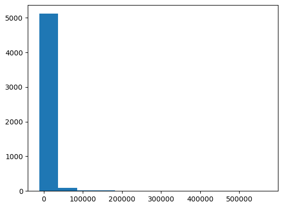

```python
import matplotlib.pyplot as plt
plt.hist(crsp_comp['revt'], bins=12)
plt.show()
```

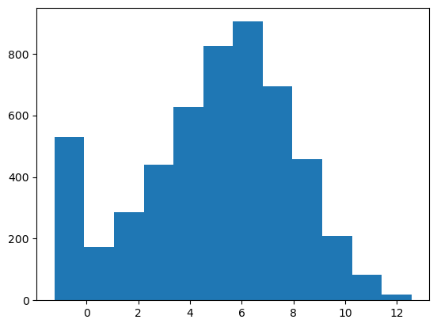

```python
import matplotlib.pyplot as plt
plt.hist(crsp_comp['log_revt'], bins=12)
plt.show()   #final project use log_rev and not rev
```

```python
import numpy as np
crsp_comp['norm'] = (1+crsp_comp.revt)/2
crsp_comp['log_revt'] = np.log(crsp_comp['norm'])
crsp_comp.head()
```

|  | Model | permno | evtdate | cret | car | bhar | nrets | nrets_est | siccd | ticker | ... | gvkey | datadate | conm | revt | ni | semiconductor | electronics components not elsewhere classified | norm | log_revt | electronics |
| --- | --- | --- | --- | --- | --- | --- | --- | --- | --- | --- | --- | --- | --- | --- | --- | --- | --- | --- | --- | --- | --- |
| 0 | Market-Adjusted Model | 10026 | 2022-08-09 | 0.116031 | 0.066420 | 0.070540 | 21 | 100 | 2052 | JJSF | ... | 012825 | 2022-09-30 | J & J SNACK FOODS CORP | 1380.656 | 47.235 | False | False | 690.828 | 6.537891 | False |
| 1 | Market-Adjusted Model | 10028 | 2022-08-09 | 0.093315 | 0.060897 | 0.047823 | 21 | 100 | 5094 | ELA | ... | 012096 | 2022-12-31 | ENVELA CORP | 182.686 | 15.689 | False | False | 91.843 | 4.520081 | False |
| 2 | Market-Adjusted Model | 10032 | 2022-08-09 | 0.107471 | 0.059075 | 0.061980 | 21 | 100 | 3670 | PLXS | ... | 012945 | 2022-09-30 | PLEXUS CORP | 3811.368 | 138.243 | False | True | 1906.184 | 7.552859 | True |
| 3 | Market-Adjusted Model | 10044 | 2022-08-09 | 0.010219 | -0.031283 | -0.035273 | 21 | 100 | 2060 | RMCF | ... | 011976 | 2022-02-28 | ROCKY MOUNTAIN CHOC FACT INC | 32.342 | -0.342 | False | False | 16.671 | 2.813671 | False |
| 4 | Market-Adjusted Model | 10065 | 2022-08-09 | 0.046098 | 0.000107 | 0.000606 | 21 | 100 | 6722 | ADX | ... | 001119 | 2022-12-31 | ADAMS DIVERSIFIED EQUITY FD | NaN | NaN | False | False | NaN | NaN | False |

5 rows × 25 columns

The trend of CAR and revenue by industry by comparing the indsutry.

```
Cumulative Abnormal Return (CAR) by Industry:
semiconductor
0    0.009746
1    0.017285
Name: car, dtype: float64

Mean Revenue by Industry:
semiconductor
0    5325.226623
1    7426.202244
Name: revt, dtype: float64
```

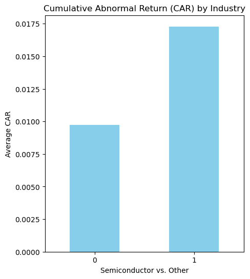

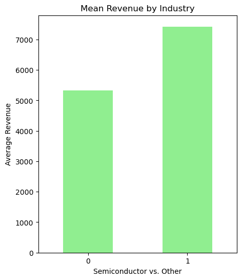

```python
#semiconductor industry
comparison_car = crsp_comp[['car', 'semiconductor']]
comparison_car = comparison_car.groupby('semiconductor')['car'].mean() #cummulative abnormal return(car)-> indicator of stock price doing well

comparison_revenue = crsp_comp[['revt', 'semiconductor']]
comparison_revenue = comparison_revenue.groupby('semiconductor')['revt'].mean()

print("Cumulative Abnormal Return (CAR) by Industry:")
print(comparison_car)

print("\nMean Revenue by Industry:")
print(comparison_revenue)


# Plotting the comparison for CAR by Industry
plt.figure(figsize=(5, 6))
comparison_car.plot(kind='bar', color='skyblue')
plt.title('Cumulative Abnormal Return (CAR) by Industry')
plt.xlabel('Semiconductor vs. Other')
plt.ylabel('Average CAR')
plt.xticks(rotation=0)
plt.show()

# Plotting the comparison for Mean Revenue by Industry
plt.figure(figsize=(5, 6))
comparison_revenue.plot(kind='bar', color='lightgreen')
plt.title('Mean Revenue by Industry')
plt.xlabel('Semiconductor vs. Other')
plt.ylabel('Average Revenue')
plt.xticks(rotation=0)
plt.show()
```

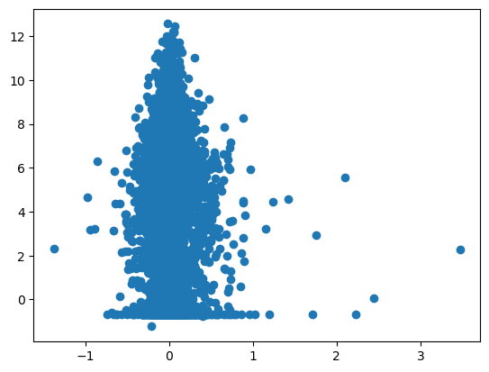

```python
plt.scatter(crsp_comp['car'],crsp_comp['log_revt'])
plt.show()
```

```
Cumulative Abnormal Return (CAR) by Industry:
electronics
0    0.009613
1    0.021187
Name: car, dtype: float64

Mean Revenue by Industry:
electronics
0    5317.560629
1    6692.243141
Name: revt, dtype: float64
```

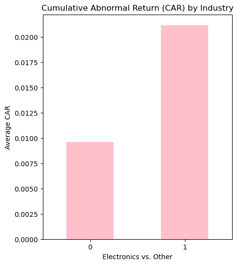

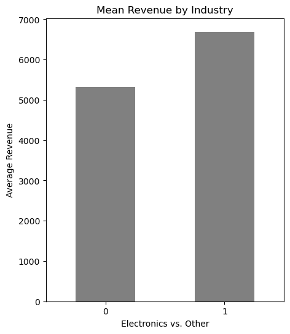

```python
# electronics industry
comparison_car = crsp_comp[['car', 'electronics']]
comparison_car = comparison_car.groupby('electronics')['car'].mean() #cummulative abnormal return(car)-> indicator of stock price doing well

comparison_revenue = crsp_comp[['revt', 'electronics']]
comparison_revenue = comparison_revenue.groupby('electronics')['revt'].mean()

print("Cumulative Abnormal Return (CAR) by Industry:")
print(comparison_car)

print("\nMean Revenue by Industry:")
print(comparison_revenue)

# Plotting the comparison for CAR by Industry
plt.figure(figsize=(5, 6))
comparison_car.plot(kind='bar', color='pink')
plt.title('Cumulative Abnormal Return (CAR) by Industry')
plt.xlabel('Electronics vs. Other')
plt.ylabel('Average CAR')
plt.xticks(rotation=0)
plt.show()

# Plotting the comparison for Mean Revenue by Industry
plt.figure(figsize=(5, 6))
comparison_revenue.plot(kind='bar', color='grey')
plt.title('Mean Revenue by Industry')
plt.xlabel('Electronics vs. Other')
plt.ylabel('Average Revenue')
plt.xticks(rotation=0)
plt.show()
```

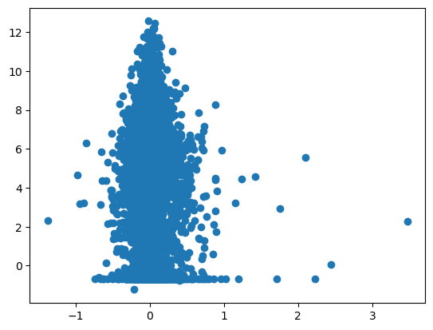

```python
plt.scatter(crsp_comp['car'],crsp_comp['log_revt'])
plt.show()
```

## p4-3. correlation

```python
correlation_data =crsp_comp[['car','revt','log_revt', 'ni']]
correlation_matrix = correlation_data.cor()
```

```python
# Select the relevant columns (CAR and control variables)
correlation_data = crsp_comp[['car', 'log_revt', 'semiconductor', 'electronics', 'revt']]  # Include other control variables here

# Calculate correlation matrix
correlation_matrix = correlation_data.corr()

# Display the correlation matrix
print(correlation_matrix)
```

```
                    car  log_revt  semiconductor  electronics      revt
car            1.000000 -0.043649       0.003453     0.007905 -0.006342
log_revt      -0.043649  1.000000       0.034127     0.044613  0.387258
semiconductor  0.003453  0.034127       1.000000     0.664539  0.007891
electronics    0.007905  0.044613       0.664539     1.000000  0.007696
revt          -0.006342  0.387258       0.007891     0.007696  1.000000
```

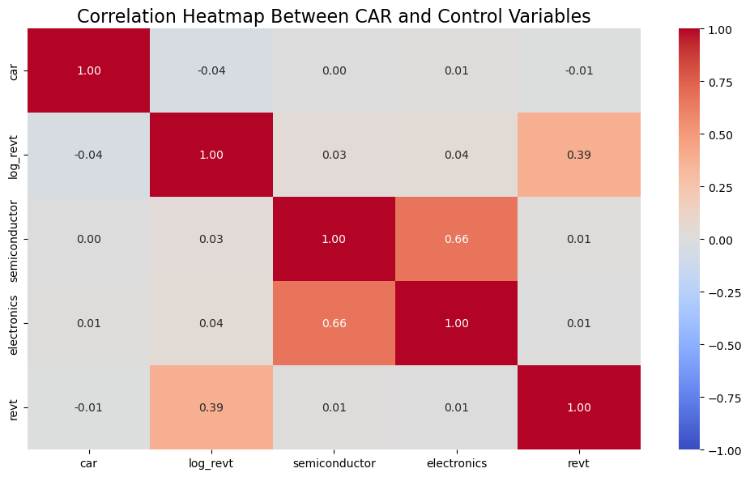

```python
import seaborn as sns
import matplotlib.pyplot as plt

plt.figure(figsize=(10, 6))
sns.heatmap(correlation_matrix, annot=True, cmap='coolwarm', fmt='.2f', vmin=-1, vmax=1)


plt.title('Correlation Heatmap Between CAR and Control Variables', fontsize=16)
plt.tight_layout()
plt.show()
```

## P4-4 - Regression models :- the models are as follows

#### 1. Regression model for the semiconductor industry

```python
import statsmodels.formula.api as smf
model1 = smf.ols(formula='car ~ semiconductor', data=crsp_comp)
results1 = model1.fit()
print(results1.summary())
```

```
                            OLS Regression Results
==============================================================================
Dep. Variable:                    car   R-squared:                       0.000
Model:                            OLS   Adj. R-squared:                 -0.000
Method:                 Least Squares   F-statistic:                   0.06748
Date:                Sun, 24 Nov 2024   Prob (F-statistic):              0.795
Time:                        21:55:36   Log-Likelihood:                 1516.8
No. Observations:                5662   AIC:                            -3030.
Df Residuals:                    5660   BIC:                            -3016.
Df Model:                           1
Covariance Type:            nonrobust
=========================================================================================
                            coef    std err          t      P>|t|      [0.025      0.975]
-----------------------------------------------------------------------------------------
Intercept                 0.0097      0.002      3.947      0.000       0.005       0.015
semiconductor[T.True]     0.0075      0.029      0.260      0.795      -0.049       0.064
==============================================================================
Omnibus:                     4371.686   Durbin-Watson:                   1.985
Prob(Omnibus):                  0.000   Jarque-Bera (JB):           389175.915
Skew:                           3.039   Prob(JB):                         0.00
Kurtosis:                      43.158   Cond. No.                         11.8
==============================================================================

Notes:
[1] Standard Errors assume that the covariance matrix of the errors is correctly specified.
```

#### 2. Regression model for the electronics industry

```python
import statsmodels.formula.api as smf
model2 = smf.ols(formula='car ~ electronics', data=crsp_comp)
results2 = model2.fit()
print(results2.summary())
```

```
                            OLS Regression Results
==============================================================================
Dep. Variable:                    car   R-squared:                       0.000
Model:                            OLS   Adj. R-squared:                 -0.000
Method:                 Least Squares   F-statistic:                    0.3538
Date:                Mon, 25 Nov 2024   Prob (F-statistic):              0.552
Time:                        00:04:28   Log-Likelihood:                 1516.9
No. Observations:                5662   AIC:                            -3030.
Df Residuals:                    5660   BIC:                            -3017.
Df Model:                           1
Covariance Type:            nonrobust
=======================================================================================
                          coef    std err          t      P>|t|      [0.025      0.975]
---------------------------------------------------------------------------------------
Intercept               0.0096      0.002      3.875      0.000       0.005       0.014
electronics[T.True]     0.0116      0.019      0.595      0.552      -0.027       0.050
==============================================================================
Omnibus:                     4372.521   Durbin-Watson:                   1.985
Prob(Omnibus):                  0.000   Jarque-Bera (JB):           389403.663
Skew:                           3.040   Prob(JB):                         0.00
Kurtosis:                      43.170   Cond. No.                         7.91
==============================================================================

Notes:
[1] Standard Errors assume that the covariance matrix of the errors is correctly specified.
```

#### 3. Regression model for the semiconductor and log_revt

```python
import statsmodels.formula.api as smf
model3 = smf.ols(formula='car ~ semiconductor+log_revt', data=crsp_comp)
results3 = model3.fit()
print(results3.summary())
```

```
                            OLS Regression Results
==============================================================================
Dep. Variable:                    car   R-squared:                       0.002
Model:                            OLS   Adj. R-squared:                  0.002
Method:                 Least Squares   F-statistic:                     5.040
Date:                Mon, 25 Nov 2024   Prob (F-statistic):            0.00651
Time:                        00:04:49   Log-Likelihood:                 1228.2
No. Observations:                5242   AIC:                            -2450.
Df Residuals:                    5239   BIC:                            -2431.
Df Model:                           2
Covariance Type:            nonrobust
=========================================================================================
                            coef    std err          t      P>|t|      [0.025      0.975]
-----------------------------------------------------------------------------------------
Intercept                 0.0261      0.005      5.062      0.000       0.016       0.036
semiconductor[T.True]     0.0084      0.030      0.281      0.779      -0.050       0.067
log_revt                 -0.0028      0.001     -3.170      0.002      -0.005      -0.001
==============================================================================
Omnibus:                     3874.278   Durbin-Watson:                   1.993
Prob(Omnibus):                  0.000   Jarque-Bera (JB):           307543.448
Skew:                           2.861   Prob(JB):                         0.00
Kurtosis:                      40.085   Cond. No.                         66.0
==============================================================================

Notes:
[1] Standard Errors assume that the covariance matrix of the errors is correctly specified.
```

#### 4. Regression model for the electronics and log_revt

```python
model4 = smf.ols(formula='car ~ electronics+log_revt', data=crsp_comp)
results4 = model4.fit()
print(results4.summary())
```

```
                            OLS Regression Results
==============================================================================
Dep. Variable:                    car   R-squared:                       0.002
Model:                            OLS   Adj. R-squared:                  0.002
Method:                 Least Squares   F-statistic:                     5.180
Date:                Mon, 25 Nov 2024   Prob (F-statistic):            0.00566
Time:                        00:05:21   Log-Likelihood:                 1228.4
No. Observations:                5242   AIC:                            -2451.
Df Residuals:                    5239   BIC:                            -2431.
Df Model:                           2
Covariance Type:            nonrobust
=======================================================================================
                          coef    std err          t      P>|t|      [0.025      0.975]
---------------------------------------------------------------------------------------
Intercept               0.0261      0.005      5.047      0.000       0.016       0.036
electronics[T.True]     0.0121      0.020      0.599      0.549      -0.027       0.052
log_revt               -0.0029      0.001     -3.186      0.001      -0.005      -0.001
==============================================================================
Omnibus:                     3874.849   Durbin-Watson:                   1.993
Prob(Omnibus):                  0.000   Jarque-Bera (JB):           307694.608
Skew:                           2.862   Prob(JB):                         0.00
Kurtosis:                      40.094   Cond. No.                         44.3
==============================================================================

Notes:
[1] Standard Errors assume that the covariance matrix of the errors is correctly specified.
```

#### 5. Regression model for the semiconductor, log_revt and industry dummies

```python
crsp_comp['sic2'] = (crsp_comp['siccd']/100).astype(int)
model5=smf.ols(formula='car~ semiconductor+C(sic2)+log_revt',data=crsp_comp)
results5 = model5.fit()
print(results5.summary())
```

```
                            OLS Regression Results
==============================================================================
Dep. Variable:                    car   R-squared:                       0.026
Model:                            OLS   Adj. R-squared:                  0.012
Method:                 Least Squares   F-statistic:                     1.857
Date:                Mon, 25 Nov 2024   Prob (F-statistic):           1.33e-05
Time:                        00:07:29   Log-Likelihood:                 1292.0
No. Observations:                5242   AIC:                            -2434.
Df Residuals:                    5167   BIC:                            -1942.
Df Model:                          74
Covariance Type:            nonrobust
=========================================================================================
                            coef    std err          t      P>|t|      [0.025      0.975]
-----------------------------------------------------------------------------------------
Intercept                -0.0055      0.040     -0.137      0.891      -0.083       0.073
semiconductor[T.True]    -0.0037      0.034     -0.108      0.914      -0.070       0.063
C(sic2)[T.1]              0.0760      0.094      0.807      0.419      -0.108       0.260
C(sic2)[T.2]             -0.0710      0.195     -0.365      0.715      -0.453       0.311
C(sic2)[T.7]              0.0023      0.087      0.026      0.979      -0.169       0.174
C(sic2)[T.9]              0.5248      0.195      2.697      0.007       0.143       0.906
C(sic2)[T.10]             0.0455      0.045      1.016      0.310      -0.042       0.133
C(sic2)[T.12]             0.1321      0.078      1.686      0.092      -0.021       0.286
C(sic2)[T.13]             0.1322      0.044      3.019      0.003       0.046       0.218
C(sic2)[T.14]             0.1150      0.068      1.693      0.090      -0.018       0.248
C(sic2)[T.15]            -0.0747      0.059     -1.278      0.201      -0.189       0.040
C(sic2)[T.16]             0.0647      0.072      0.894      0.371      -0.077       0.206
C(sic2)[T.17]             0.0569      0.065      0.880      0.379      -0.070       0.184
C(sic2)[T.20]             0.0439      0.046      0.953      0.341      -0.046       0.134
C(sic2)[T.21]            -0.0978      0.094     -1.039      0.299      -0.282       0.087
C(sic2)[T.22]            -0.0710      0.072     -0.983      0.325      -0.213       0.071
C(sic2)[T.23]             0.0091      0.063      0.143      0.886      -0.115       0.133
C(sic2)[T.24]            -0.0260      0.070     -0.372      0.710      -0.163       0.111
C(sic2)[T.25]             0.0208      0.068      0.305      0.760      -0.112       0.154
C(sic2)[T.26]             0.0457      0.060      0.759      0.448      -0.072       0.164
C(sic2)[T.27]            -0.0132      0.056     -0.236      0.813      -0.122       0.096
C(sic2)[T.28]             0.0381      0.042      0.918      0.359      -0.043       0.120
C(sic2)[T.29]             0.1425      0.060      2.396      0.017       0.026       0.259
C(sic2)[T.30]             0.1203      0.060      2.003      0.045       0.003       0.238
C(sic2)[T.31]            -0.0444      0.082     -0.539      0.590      -0.206       0.117
C(sic2)[T.32]             0.0584      0.063      0.923      0.356      -0.066       0.183
```

[output cut: 43 more lines]

```
C(sic2)[T.87]             0.0499      0.045      1.117      0.264      -0.038       0.138
C(sic2)[T.89]             0.2040      0.195      1.048      0.295      -0.178       0.586
C(sic2)[T.96]             0.0970      0.195      0.498      0.618      -0.285       0.479
C(sic2)[T.97]            -0.0327      0.195     -0.168      0.867      -0.414       0.349
C(sic2)[T.99]             0.0347      0.040      0.867      0.386      -0.044       0.113
log_revt                 -0.0036      0.001     -3.388      0.001      -0.006      -0.002
==============================================================================
Omnibus:                     3942.675   Durbin-Watson:                   1.999
Prob(Omnibus):                  0.000   Jarque-Bera (JB):           336320.367
Skew:                           2.920   Prob(JB):                         0.00
Kurtosis:                      41.803   Cond. No.                         774.
==============================================================================

Notes:
[1] Standard Errors assume that the covariance matrix of the errors is correctly specified.
```

#### 6. Regression model for the electronics , log_revt and industry dummies

```python
crsp_comp['sic2'] = (crsp_comp['siccd']/100).astype(int)
model6=smf.ols(formula='car~electronics+C(sic2)+log_revt',data=crsp_comp)
results6 = model6.fit()
print(results6.summary())
```

```
                            OLS Regression Results
==============================================================================
Dep. Variable:                    car   R-squared:                       0.026
Model:                            OLS   Adj. R-squared:                  0.012
Method:                 Least Squares   F-statistic:                     1.857
Date:                Mon, 25 Nov 2024   Prob (F-statistic):           1.33e-05
Time:                        00:09:04   Log-Likelihood:                 1292.0
No. Observations:                5242   AIC:                            -2434.
Df Residuals:                    5167   BIC:                            -1942.
Df Model:                          74
Covariance Type:            nonrobust
=======================================================================================
                          coef    std err          t      P>|t|      [0.025      0.975]
---------------------------------------------------------------------------------------
Intercept              -0.0054      0.040     -0.137      0.891      -0.083       0.073
electronics[T.True]     0.0011      0.028      0.038      0.969      -0.054       0.056
C(sic2)[T.1]            0.0760      0.094      0.808      0.419      -0.108       0.260
C(sic2)[T.2]           -0.0710      0.195     -0.365      0.715      -0.453       0.311
C(sic2)[T.7]            0.0023      0.087      0.026      0.979      -0.169       0.174
C(sic2)[T.9]            0.5248      0.195      2.697      0.007       0.143       0.906
C(sic2)[T.10]           0.0455      0.045      1.016      0.310      -0.042       0.133
C(sic2)[T.12]           0.1321      0.078      1.686      0.092      -0.021       0.286
C(sic2)[T.13]           0.1323      0.044      3.020      0.003       0.046       0.218
C(sic2)[T.14]           0.1150      0.068      1.693      0.090      -0.018       0.248
C(sic2)[T.15]          -0.0747      0.059     -1.277      0.202      -0.189       0.040
C(sic2)[T.16]           0.0647      0.072      0.894      0.371      -0.077       0.206
C(sic2)[T.17]           0.0569      0.065      0.880      0.379      -0.070       0.184
C(sic2)[T.20]           0.0439      0.046      0.953      0.341      -0.046       0.134
C(sic2)[T.21]          -0.0978      0.094     -1.039      0.299      -0.282       0.087
C(sic2)[T.22]          -0.0710      0.072     -0.983      0.326      -0.213       0.071
C(sic2)[T.23]           0.0091      0.063      0.143      0.886      -0.115       0.133
C(sic2)[T.24]          -0.0260      0.070     -0.371      0.710      -0.163       0.111
C(sic2)[T.25]           0.0208      0.068      0.305      0.760      -0.112       0.154
C(sic2)[T.26]           0.0457      0.060      0.760      0.448      -0.072       0.164
C(sic2)[T.27]          -0.0132      0.056     -0.236      0.813      -0.122       0.096
C(sic2)[T.28]           0.0381      0.042      0.918      0.359      -0.043       0.120
C(sic2)[T.29]           0.1426      0.060      2.396      0.017       0.026       0.259
C(sic2)[T.30]           0.1204      0.060      2.003      0.045       0.003       0.238
C(sic2)[T.31]          -0.0444      0.082     -0.539      0.590      -0.206       0.117
C(sic2)[T.32]           0.0584      0.063      0.923      0.356      -0.066       0.183
```

[output cut: 43 more lines]

```
C(sic2)[T.87]           0.0499      0.045      1.117      0.264      -0.038       0.138
C(sic2)[T.89]           0.2040      0.195      1.048      0.295      -0.178       0.586
C(sic2)[T.96]           0.0970      0.195      0.498      0.618      -0.285       0.479
C(sic2)[T.97]          -0.0327      0.195     -0.168      0.867      -0.414       0.349
C(sic2)[T.99]           0.0347      0.040      0.867      0.386      -0.044       0.113
log_revt               -0.0036      0.001     -3.390      0.001      -0.006      -0.002
==============================================================================
Omnibus:                     3942.556   Durbin-Watson:                   2.000
Prob(Omnibus):                  0.000   Jarque-Bera (JB):           336307.053
Skew:                           2.920   Prob(JB):                         0.00
Kurtosis:                      41.803   Cond. No.                         774.
==============================================================================

Notes:
[1] Standard Errors assume that the covariance matrix of the errors is correctly specified.
```

#### 7. Regression model for the positive net income for the semiconductor industyr

```python
crsp_comp_profit=crsp_comp[(crsp_comp['ni'] >= 0)]
model7=smf.ols(formula='car ~ semiconductor+log_revt', data=crsp_comp_profit)
results7 = model7.fit()
print(results7.summary())
```

```
                            OLS Regression Results
==============================================================================
Dep. Variable:                    car   R-squared:                       0.001
Model:                            OLS   Adj. R-squared:                 -0.000
Method:                 Least Squares   F-statistic:                    0.7775
Date:                Mon, 25 Nov 2024   Prob (F-statistic):              0.460
Time:                        00:10:39   Log-Likelihood:                 1837.5
No. Observations:                2803   AIC:                            -3669.
Df Residuals:                    2800   BIC:                            -3651.
Df Model:                           2
Covariance Type:            nonrobust
=========================================================================================
                            coef    std err          t      P>|t|      [0.025      0.975]
-----------------------------------------------------------------------------------------
Intercept                 0.0166      0.008      2.189      0.029       0.002       0.032
semiconductor[T.True]     0.0083      0.025      0.333      0.739      -0.040       0.057
log_revt                 -0.0014      0.001     -1.214      0.225      -0.004       0.001
==============================================================================
Omnibus:                     1172.494   Durbin-Watson:                   1.995
Prob(Omnibus):                  0.000   Jarque-Bera (JB):            23472.236
Skew:                           1.485   Prob(JB):                         0.00
Kurtosis:                      16.862   Cond. No.                         71.8
==============================================================================

Notes:
[1] Standard Errors assume that the covariance matrix of the errors is correctly specified.
```

#### 8. Regression model for the positive net income for the electronics industry

```python
crsp_comp_profit=crsp_comp[(crsp_comp['ni'] >= 0)]
model8=smf.ols(formula='car ~ electronics+log_revt', data=crsp_comp_profit)
results8 = model8.fit()
print(results8.summary())
```

```
                            OLS Regression Results
==============================================================================
Dep. Variable:                    car   R-squared:                       0.001
Model:                            OLS   Adj. R-squared:                  0.001
Method:                 Least Squares   F-statistic:                     1.748
Date:                Mon, 25 Nov 2024   Prob (F-statistic):              0.174
Time:                        01:02:33   Log-Likelihood:                 1838.4
No. Observations:                2803   AIC:                            -3671.
Df Residuals:                    2800   BIC:                            -3653.
Df Model:                           2
Covariance Type:            nonrobust
===============================================================================
                  coef    std err          t      P>|t|      [0.025      0.975]
-------------------------------------------------------------------------------
Intercept       0.0164      0.008      2.161      0.031       0.002       0.031
electronics     0.0229      0.016      1.432      0.152      -0.008       0.054
log_revt       -0.0014      0.001     -1.245      0.213      -0.004       0.001
==============================================================================
Omnibus:                     1172.340   Durbin-Watson:                   1.993
Prob(Omnibus):                  0.000   Jarque-Bera (JB):            23526.360
Skew:                           1.484   Prob(JB):                         0.00
Kurtosis:                      16.879   Cond. No.                         46.4
==============================================================================

Notes:
[1] Standard Errors assume that the covariance matrix of the errors is correctly specified.
```

References:- http://localhost:8891/notebooks/Kubra/Downloads/in-class10_F24_shared.ipynb (all the class notes and materials) Textbooks/Daniel Y. Chen-Pandas for Everyone.%20 Python Data Analysis-Addison-Wesley Professional (2017).pdf